# Replicating Principal Component Analysis

The launching point for the discussion was this paper: [Scale and information-processing thresholds in Holocene social evolution](https://wiki.santafe.edu/images/6/60/Shin2020_scaleinformationthresholds.pdf) by Jaeweon Shin and his coauthors. Replication code is available at https://github.com/jaewshin/Holocene.

The paper leverages the Seshat database of hundreds of polities over thousands of years. In an [earlier paper](https://www.pnas.org/content/115/2/E144), Turchin and coauthors used 50+ variables in Seshat to construct 9 variables that measured social complexity. They used PCA to flatten these variables, and found that the first PCA component explained 77% of the variation in the data. In other words, societies seem to evolve along a single primary dimension of complexity.

Shin et. al. examine the second PCA component, wich explains a further 6% of the variation. They note a sinusoidal pattern, which leads them to conclude, "We find that sociopolitical development is dominated first by growth in polity scale, then by improvements in information processing and economic systems, and then by further increases in scale." Much of the subsequent research agenda is driven by the discovery of these two "hinge points" between polity growth and information technology.

## My Question

The evidence for the two hinge points rests on a long chain of evidence. The Seshat creators code 1500 variables, Turchin chooses 50 and constructs 9 complexity variables, and then Shin flattens those complexity variables using PCA. I was curious about the variables that actually went into PCA2 and drove the analysis. I figured this would also be a good chance to learn more about PCA.

```python
import pandas as pd
import numpy as np
from sklearn.preprocessing import StandardScaler
from sklearn.decomposition import PCA
from matplotlib import pyplot as plt
from scipy.stats import pearsonr
```

```python
# Load Shin's starting data, which comes from Turchin and includes the 9 complexity variables
d = pd.read_csv('data1.csv')
```

The first thing I did was look at histograms of the variables feeding PCA2. Most appeared fairly continuous, but **writing** and **texts** were heavily loaded in PCA2 and showed a strong bimodal distribution; these did not rise continuously over time, but appeared to "switch on" at certain points in a polity's history.

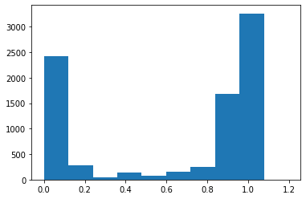

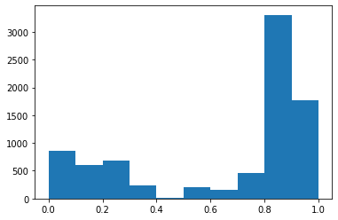

```python
plt.hist(d['texts'])
plt.show()

plt.hist(d['writing'])
plt.show()
```

Furthermore, these two variables are highly correlated.

```python
pearsonr(d['writing'], d['texts'])
```

```
(0.9008946369780639, 0.0)
```

Was it possible that this sudden "switching on" of writing was swamping the other data? To check, I decided to replicate the PCA and then remove writing and texts.

The replication code was incredibly complex. The authors implemented most of the key methods themselves using standard libraries, and the code included mysteries I still don't understand, such as loading and using two different copies of the same dataset in the same calculation.

I opted to begin by using sklearn to implement PCA.

```python
def run_pca(pc_vars):
    d = pd.read_csv('data1.csv')
    raw_matrix = d[pc_vars]
    scaled_matrix = StandardScaler().fit_transform(raw_matrix)

    pca = PCA(n_components=2)
    principalComponents = pca.fit_transform(scaled_matrix)
    principalDf = pd.DataFrame(data=principalComponents, columns=['PC1', 'PC2'])

    # See https://stackoverflow.com/questions/21217710/factor-loadings-using-sklearn
    loadings = pd.DataFrame(pca.components_.T * np.sqrt(pca.explained_variance_), columns=['PC1','PC2'], index=pc_vars)

    print(pca.explained_variance_ratio_)
    print(loadings)

pc_vars = ['PolPop', 'PolTerr', 'CapPop', 'levels', 'government', 'infrastr', 'texts', 'writing', 'money']
run_pca(pc_vars)
```

```
[0.77214914 0.05973755]
                 PC1       PC2
PolPop     -0.927575 -0.248479
PolTerr    -0.848820 -0.348062
CapPop     -0.888208 -0.273982
levels     -0.899314 -0.150166
government -0.877833  0.094731
infrastr   -0.877551  0.123563
texts      -0.921088  0.237218
writing    -0.865982  0.310443
money      -0.795362  0.283388
```

These results almost perfectly replicate the Shin paper. PCA1 explains 77.2% of the variance, PCA2 explains 6% of the variance, and the magnitude of the PCA loadings matches. However, all the PCA1 loading signs are negative, while they are positive in the paper. Googling eventually led me to discover that sklearn's implementation of PCA results in flipped signs sometimes. See https://stackoverflow.com/questions/44765682/in-sklearn-decomposition-pca-why-are-components-negative.

It appears the only way to replicate the paper was to implement my own PCA method, which was pretty easy using the singular value decomposition method in numpy. This method replicates the Shin paper with the proper signs.

```python
# My own implementation of PCA, which gets the signs correct.
# Code based on looking at the sklearn source code and the seshat.py code
# Returns:
#   principal components (DataFrame nrows x n_components)
#   explained variance ratio (array of n_components)
#   loadings (DataFrame n_factors x n_components)
def run_custom_pca(pc_vars, n_components):
    d = pd.read_csv('data1.csv')
    raw_matrix = d[pc_vars]
    scaled_matrix = StandardScaler().fit_transform(raw_matrix)

    U, S, V = np.linalg.svd(scaled_matrix, full_matrices=False)

    n_samples, n_features = scaled_matrix.shape
    explained_variance_ = (S ** 2) / (n_samples - 1)
    total_var = explained_variance_.sum()
    explained_variance_ratio = explained_variance_ / total_var

    loadings = pd.DataFrame(V.T * np.sqrt(explained_variance_), index=pc_vars)

    pc = np.matmul(scaled_matrix, V.T)

    return(pc[:, 0:n_components], explained_variance_ratio[0:n_components], loadings.iloc[:, 0:n_components])
```

```python
pc_vars = ['PolPop', 'PolTerr', 'CapPop', 'levels', 'government', 'infrastr', 'writing', 'texts', 'money']

U, explained_variance_ratio, loadings = run_custom_pca(pc_vars, n_components=2)
print(explained_variance_ratio)
print(loadings)
```

```
[0.77214914 0.05973755]
                   0         1
PolPop      0.927575 -0.248479
PolTerr     0.848820 -0.348062
CapPop      0.888208 -0.273982
levels      0.899314 -0.150166
government  0.877833  0.094731
infrastr    0.877551  0.123563
writing     0.865982  0.310443
texts       0.921088  0.237218
money       0.795362  0.283388
```

```python
pc_vars = ['PolPop', 'PolTerr', 'CapPop', 'levels', 'government', 'infrastr', 'money']

U, explained_variance_ratio, loadings = run_custom_pca(pc_vars, n_components=2)
print(explained_variance_ratio)
print(loadings)
```

```
[0.77738106 0.0661246 ]
                   0         1
PolPop      0.942130 -0.192589
PolTerr     0.861607 -0.375788
CapPop      0.907378 -0.172326
levels      0.912653 -0.040326
government  0.876168  0.197351
infrastr    0.875326  0.248037
money       0.788804  0.390933
```